# Analysis of Weightlifting exercise

Balavinayak R

March 01, 2018

# Introduction

This study analyzes data from accelerometers on the belt, forearm, arm & dumbell of 6 participants to predict the manner in which they executed the weightlifting exercise. The *classe* variable in the dataset which holds this information has 5 possible values - Class A through Class E, where Class A corresponds to the correct manner of performing the exercise and Classes B through E are different incorrect executions of the exercise.

# Getting & cleaning the data

The training dataset is downloaded from the URL, https://d396qusza40orc.cloudfront.net/predmachlearn/pml-training.csv

```r
origData <- read.csv("https://d396qusza40orc.cloudfront.net/predmachlearn/pml-training.csv",
                      stringsAsFactors = FALSE,
                      na.strings = c("", NA))
#Inspect the dataset.
str(origData)
```

```
'data.frame':   19622 obs. of  160 variables:
 $ X                       : int  1 2 3 4 5 6 7 8 9 10 ...
 $ user_name               : chr  "carlitos" "carlitos" "carlitos" "carlitos" ...
 $ raw_timestamp_part_1    : int  1323084231 1323084231 1323084231 1323084232 1323084232 1323084232 1323084232 1323084232 1323084232 1323084232 ...
 $ raw_timestamp_part_2    : int  788290 808298 820366 120339 196328 304277 368296 440390 484323 484434 ...
 $ cvtd_timestamp          : chr  "05/12/2011 11:23" "05/12/2011 11:23" "05/12/2011 11:23" "05/12/2011 11:23" ...
 $ new_window              : chr  "no" "no" "no" "no" ...
 $ num_window              : int  11 11 11 12 12 12 12 12 12 12 ...
 $ roll_belt               : num  1.41 1.41 1.42 1.48 1.48 1.45 1.42 1.42 1.43 1.45 ...
 $ pitch_belt              : num  8.07 8.07 8.07 8.05 8.07 8.06 8.09 8.13 8.16 8.17 ...
 $ yaw_belt                : num  -94.4 -94.4 -94.4 -94.4 -94.4 -94.4 -94.4 -94.4 -94.4 -94.4 ...
 $ total_accel_belt        : int  3 3 3 3 3 3 3 3 3 3 ...
 $ kurtosis_roll_belt      : chr  NA NA NA NA ...
 $ kurtosis_picth_belt     : chr  NA NA NA NA ...
 $ kurtosis_yaw_belt       : chr  NA NA NA NA ...
```

[output cut: 86 more lines]

We see that the dataset has missing values in many columns. On inspection, we find that the columns which have most of their values as NA are summary fields like Kurtosis, Skewness, Average, Variance etc. These columns will be removed from the dataset for further processing.

```r
naCount <- sapply(origData, function(x) sum(is.na(x)))
nonSummary_fields <- names(naCount[naCount == 0])
data <- select(origData, nonSummary_fields)
#Retain only the activity features in the data set.
data <- data[,8:ncol(data)]
#Create training & validation datasets in an 80:20 ratio.
set.seed(10)
index <- createDataPartition(data$classe, p = 0.8, list = FALSE)
trainingData <- data[index,]
validationData <- data[-index,]
```

This analysis involves a multi-class classification problem. We will use the following algorithms to classify the observations to one of Class A through E. - Classification trees - Bagging - Boosting - Random forest The *train* function from the *caret* package is used to cross-validate all the models. The built models will be compared against each other in terms of their accuracy & other metrics while predicting on the validation dataset.

A custom *trainControl* object is defined at the outset, to be used with all models built using *train*. The *k-fold cross-validation* technique was preferred to the usual training & test set validation for better accuracy. *k* was chosen as 10 in view of the computational requirements of the more accurate Leave One Out Cross Validation (LOOCV) technique. The Near-zero variance pre-processing method was used to remove predictors with constant or near-constant variance.

## Classification tree

```r
myControl <- trainControl(method = "cv",
                          number = 10,
                          verboseIter = FALSE)
set.seed(10)
classTreeModel <- train(classe~.,
                        data = trainingData,
                        method = "rpart",
                        trControl = myControl)
classTreeModel
```

```
CART

15699 samples
   52 predictor
    5 classes: 'A', 'B', 'C', 'D', 'E'

No pre-processing
Resampling: Cross-Validated (10 fold)
Summary of sample sizes: 14130, 14129, 14128, 14129, 14130, 14130, ...
Resampling results across tuning parameters:

  cp          Accuracy   Kappa
  0.03925234  0.5128366  0.37030432
  0.04218959  0.4453192  0.26281793
  0.11375167  0.3386173  0.08292142

Accuracy was used to select the optimal model using the largest value.
The final value used for the model was cp = 0.03925234.
```

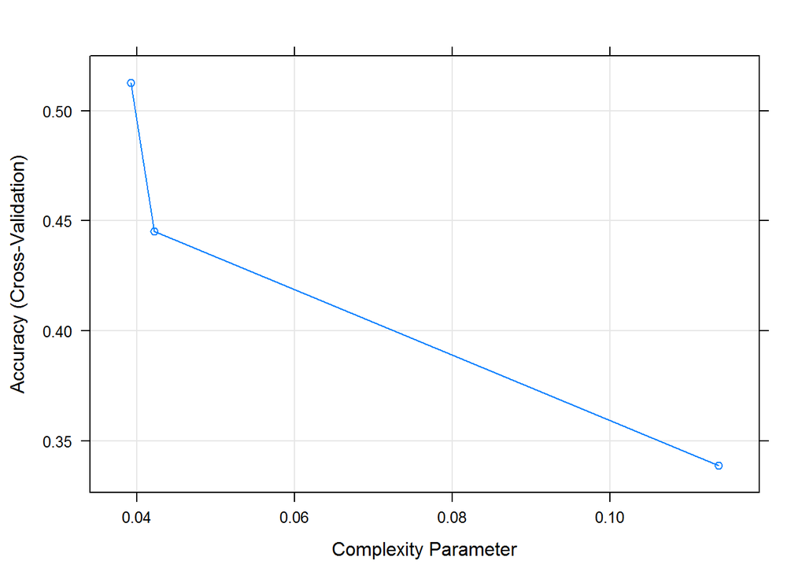

```r
#Plot showing the model accuracy for various complexity parameters.
plot(classTreeModel)
```

```r
#Validate the model using the validation dataset.
valResults <- predict(classTreeModel, validationData)
confusionMatrix(valResults, validationData$classe)
```

```
Confusion Matrix and Statistics

          Reference
Prediction   A   B   C   D   E
         A 675 116  23  46  11
         B   3 125  22   2   4
         C 212 139 450 176 136
         D 222 379 189 419 227
         E   4   0   0   0 343

Overall Statistics

               Accuracy : 0.5129
                 95% CI : (0.4971, 0.5286)
    No Information Rate : 0.2845
    P-Value [Acc > NIR] : < 2.2e-16

                  Kappa : 0.3937
 Mcnemar's Test P-Value : < 2.2e-16

Statistics by Class:

                     Class: A Class: B Class: C Class: D Class: E
Sensitivity            0.6048  0.16469   0.6579   0.6516  0.47573
Specificity            0.9302  0.99020   0.7953   0.6899  0.99875
Pos Pred Value         0.7750  0.80128   0.4043   0.2918  0.98847
Neg Pred Value         0.8555  0.83170   0.9167   0.9099  0.89430
Prevalence             0.2845  0.19347   0.1744   0.1639  0.18379
Detection Rate         0.1721  0.03186   0.1147   0.1068  0.08743
Detection Prevalence   0.2220  0.03977   0.2837   0.3660  0.08845
Balanced Accuracy      0.7675  0.57745   0.7266   0.6708  0.73724
```

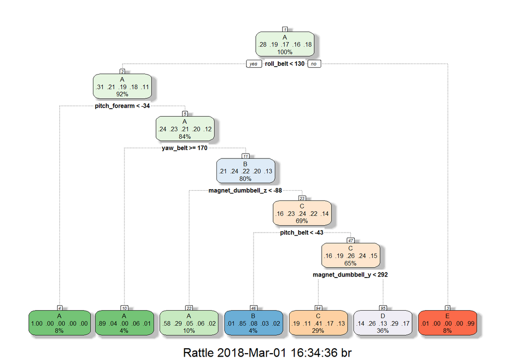

```r
fancyRpartPlot(classTreeModel$finalModel)
```

## Bagging

```r
set.seed(10)
bgModel <- train(classe ~.,
                 data = trainingData,
                 preProcess = "nzv",
                 method = "treebag",
                 trControl = myControl
                 )
bgModel
```

```
Bagged CART

15699 samples
   52 predictor
    5 classes: 'A', 'B', 'C', 'D', 'E'

Pre-processing:  (None)
Resampling: Cross-Validated (10 fold)
Summary of sample sizes: 14130, 14129, 14128, 14129, 14130, 14130, ...
Resampling results:

  Accuracy   Kappa
  0.9883429  0.9852534
```

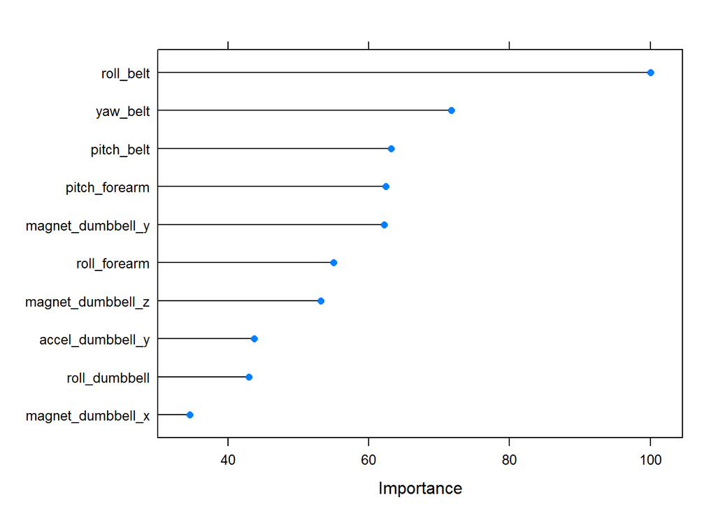

```r
#Plot the top-10 predictors by importance
plot(varImp(bgModel), top = 10)
```

```r
#Validate the model using the validation dataset.
valResults <- predict(bgModel, validationData)
confusionMatrix(valResults, validationData$classe)
```

```
Confusion Matrix and Statistics

          Reference
Prediction    A    B    C    D    E
         A 1116    3    0    0    0
         B    0  751    8    0    2
         C    0    2  671    3    1
         D    0    2    5  638    3
         E    0    1    0    2  715

Overall Statistics

               Accuracy : 0.9918
                 95% CI : (0.9885, 0.9944)
    No Information Rate : 0.2845
    P-Value [Acc > NIR] : < 2.2e-16

                  Kappa : 0.9897
 Mcnemar's Test P-Value : NA

Statistics by Class:

                     Class: A Class: B Class: C Class: D Class: E
Sensitivity            1.0000   0.9895   0.9810   0.9922   0.9917
Specificity            0.9989   0.9968   0.9981   0.9970   0.9991
Pos Pred Value         0.9973   0.9869   0.9911   0.9846   0.9958
Neg Pred Value         1.0000   0.9975   0.9960   0.9985   0.9981
Prevalence             0.2845   0.1935   0.1744   0.1639   0.1838
Detection Rate         0.2845   0.1914   0.1710   0.1626   0.1823
Detection Prevalence   0.2852   0.1940   0.1726   0.1652   0.1830
Balanced Accuracy      0.9995   0.9931   0.9896   0.9946   0.9954
```

## Gradient Boosting

```r
set.seed(10)
h2o.init()
gradboostModel <- train(classe ~.,
                 data = trainingData,
                 preProcess = "nzv",
                 method = "gbm_h2o",
                 trControl = myControl
                 )
```

```r
gradboostModel
```

```
## Gradient Boosting Machines
##
## 15699 samples
##    52 predictor
##     5 classes: 'A', 'B', 'C', 'D', 'E'
##
## Pre-processing:  (None)
## Resampling: Cross-Validated (10 fold)
## Summary of sample sizes: 14130, 14129, 14129, 14129, 14130, 14128, ...
## Resampling results across tuning parameters:
##
##   max_depth  ntrees  Accuracy   Kappa
##   1           50     0.7313206  0.6591453
##   1          100     0.7931710  0.7379777
##   1          150     0.8295432  0.7842361
##   2           50     0.8561693  0.8177908
##   2          100     0.9133702  0.8904219
##   2          150     0.9394227  0.9233587
##   3           50     0.9252182  0.9054013
##   3          100     0.9638187  0.9542255
##   3          150     0.9811443  0.9761477
##
## Tuning parameter 'min_rows' was held constant at a value of 10
##
## Tuning parameter 'learn_rate' was held constant at a value of 0.1
##
## Tuning parameter 'col_sample_rate' was held constant at a value of 1
## Accuracy was used to select the optimal model using the largest value.
## The final values used for the model were ntrees = 150, max_depth =
##  3, min_rows = 10, learn_rate = 0.1 and col_sample_rate = 1.
```

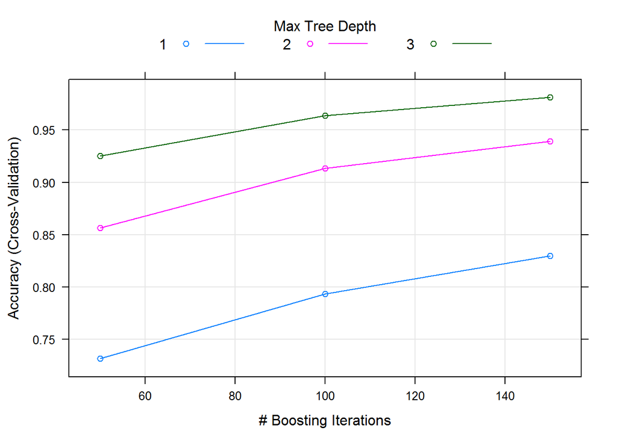

```r
#Plot showing the model accuracy for various no. of iteratios & tree depths.
plot(gradboostModel)
```

```r
#Validate the model using the validation dataset.
valResults <- predict(gradboostModel, validationData)
confusionMatrix(valResults, validationData$classe)
```

```
## Confusion Matrix and Statistics
##
##           Reference
## Prediction    A    B    C    D    E
##          A 1107    6    0    0    1
##          B    6  744   14    1    2
##          C    3    9  657   13    2
##          D    0    0   10  625    2
##          E    0    0    3    4  714
##
## Overall Statistics
##
##                Accuracy : 0.9806
##                  95% CI : (0.9758, 0.9847)
##     No Information Rate : 0.2845
##     P-Value [Acc > NIR] : < 2.2e-16
##
##                   Kappa : 0.9755
##  Mcnemar's Test P-Value : NA
##
## Statistics by Class:
##
##                      Class: A Class: B Class: C Class: D Class: E
## Sensitivity            0.9919   0.9802   0.9605   0.9720   0.9903
## Specificity            0.9975   0.9927   0.9917   0.9963   0.9978
## Pos Pred Value         0.9937   0.9700   0.9605   0.9812   0.9903
## Neg Pred Value         0.9968   0.9952   0.9917   0.9945   0.9978
## Prevalence             0.2845   0.1935   0.1744   0.1639   0.1838
## Detection Rate         0.2822   0.1897   0.1675   0.1593   0.1820
## Detection Prevalence   0.2840   0.1955   0.1744   0.1624   0.1838
## Balanced Accuracy      0.9947   0.9865   0.9761   0.9842   0.9941
```

## Random Forest

```r
set.seed(10)
rfModel <- train(classe ~.,
                 data = trainingData,
                 preProcess = "nzv",
                 method = "ranger",
                 trControl = myControl
                 )
```

```r
#Print model summary
rfModel
```

```
## Random Forest
##
## 15699 samples
##    52 predictor
##     5 classes: 'A', 'B', 'C', 'D', 'E'
##
## Pre-processing:  (None)
## Resampling: Cross-Validated (10 fold)
## Summary of sample sizes: 14130, 14129, 14128, 14129, 14130, 14130, ...
## Resampling results across tuning parameters:
##
##   mtry  splitrule   Accuracy   Kappa
##    2    gini        0.9933119  0.9915390
##    2    extratrees  0.9925479  0.9905728
##   27    gini        0.9936303  0.9919422
##   27    extratrees  0.9957325  0.9946020
##   52    gini        0.9901902  0.9875892
##   52    extratrees  0.9956052  0.9944410
##
## Tuning parameter 'min.node.size' was held constant at a value of 1
## Accuracy was used to select the optimal model using the largest value.
## The final values used for the model were mtry = 27, splitrule =
##  extratrees and min.node.size = 1.
```

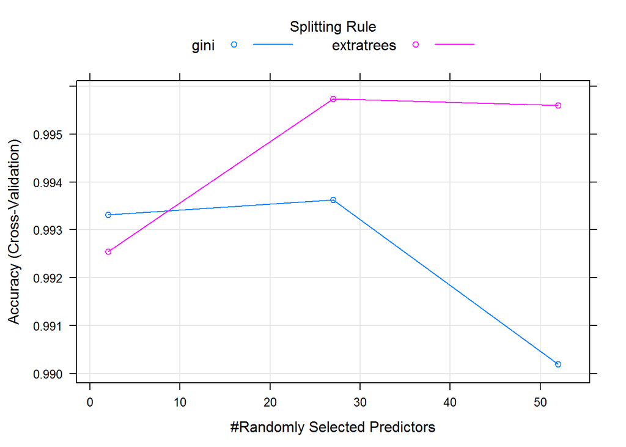

```r
#Plot showing accuracy per no. of random predictors chosen
plot(rfModel)
```

```r
#Validate the model using the validation dataset.
valResults <- predict(rfModel, validationData)
confusionMatrix(valResults, validationData$classe)
```

```
## Confusion Matrix and Statistics
##
##           Reference
## Prediction    A    B    C    D    E
##          A 1116    0    0    0    0
##          B    0  759    4    0    0
##          C    0    0  680    2    1
##          D    0    0    0  640    0
##          E    0    0    0    1  720
##
## Overall Statistics
##
##                Accuracy : 0.998
##                  95% CI : (0.996, 0.9991)
##     No Information Rate : 0.2845
##     P-Value [Acc > NIR] : < 2.2e-16
##
##                   Kappa : 0.9974
##  Mcnemar's Test P-Value : NA
##
## Statistics by Class:
##
##                      Class: A Class: B Class: C Class: D Class: E
## Sensitivity            1.0000   1.0000   0.9942   0.9953   0.9986
## Specificity            1.0000   0.9987   0.9991   1.0000   0.9997
## Pos Pred Value         1.0000   0.9948   0.9956   1.0000   0.9986
## Neg Pred Value         1.0000   1.0000   0.9988   0.9991   0.9997
## Prevalence             0.2845   0.1935   0.1744   0.1639   0.1838
## Detection Rate         0.2845   0.1935   0.1733   0.1631   0.1835
## Detection Prevalence   0.2845   0.1945   0.1741   0.1631   0.1838
## Balanced Accuracy      1.0000   0.9994   0.9966   0.9977   0.9992
```

# Retrieving the test data

The testing dataset is downloaded from the URL, https://d396qusza40orc.cloudfront.net/predmachlearn/pml-testing.csv

```r
testData <- read.csv("https://d396qusza40orc.cloudfront.net/predmachlearn/pml-testing.csv",
                      stringsAsFactors = FALSE,
                      na.strings = c("", NA))
#Preprocess the data
naCount <- sapply(testData, function(x) sum(is.na(x)))
nonSummary_fields <- names(naCount[naCount == 0])
data <- select(testData, nonSummary_fields)
#Retain only the activity features in the data set.
data <- data[,8:ncol(data) - 1]
#Use the Random Forest model to predict the classes of the test data.
(testDataResults <- predict(rfModel, data))
```

```
 [1] B A B A A E D B A A B C B A E E A B B B
Levels: A B C D E
```

# Conclusion

From the analysis performed on the dataset to classify the action into one of 5 classes, it is clear that the ensemble methods (bagging, boosting & random forest) perform much better than a classification tree. The better accuracy of the ensemble methods comes with the cost of higher computational requirements.